# Point Estimation and Intervals

The vast majority of our work in stats is to produce point estimates and intervals around that estimate. Even the simple things (e.g., means, medians) are point estimates and we frequently see confidence intervals reported.

# Point Estimation

Point estimates are just that – some single value that provides an estimation for a sample. Like every statistic we ever produce, this point can have varying levels of precision.

There are a few characteristic that a point estimate should have:

1. It should be *consistent*. Consistency in point estimation is best achieved through obtaining a sufficiently large sample from the population.

```r
population = rnorm(100000, mean = 10, sd = 2)

mean(population)
```

```
[1] 10.00445
```

```r
median(population)
```

```
[1] 10.00426
```

```r
replicate(10, mean(sample(population, 100, replace = FALSE)))
```

```
 [1]  9.937449  9.692930  9.945210 10.144980 10.001611  9.836266
 [7]  9.878540  9.908875  9.985930 10.079239
```

```r
replicate(10, mean(sample(population, 1000, replace = FALSE)))
```

```
 [1] 10.075763 10.010920  9.971996  9.956968 10.036287  9.986202
 [7] 10.006602  9.968129 10.032218  9.970640
```

```r
replicate(10, mean(sample(population, 10000, replace = FALSE)))
```

```
 [1]  9.999984 10.001608 10.000859 10.019092  9.977971 10.028786
 [7] 10.009317 10.020768 10.012611 10.041392
```

```r
replicate(10, mean(sample(population, 50000, replace = FALSE)))
```

```
 [1]  9.999754 10.012286 10.001792 10.003401 10.003266 10.013918
 [7] 10.010382  9.991992 10.010869  9.997958
```

We can see that increasing our sample yields re-sample means that are closer to the population value.

2. It should be *unbiased*. The term unbiased can be confusing, only because it can mean different things in different statistical contexts. In most regards, though, unbiased just means that the estimate does not drift (too far) from the population value. This can be illustrated by taking the mean observation value of the sampled statistics.

```r
mean(population)
```

```
[1] 10.00445
```

```r
mean(replicate(10, mean(sample(population, 50000, replace = FALSE))))
```

```
[1] 10.00479
```

3. It should be *efficient*. Here, efficiency means that the best estimator is the one with the smallest *variance* within the sampled estimates. The mean tends to be a pretty efficient estimator for the normal distribution. It does, however, tend to fall apart when dealing with skewed distributions.

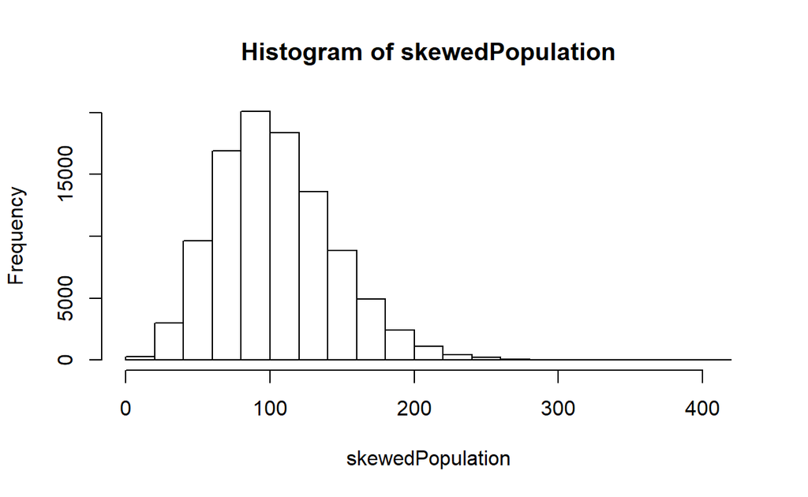

```r
skewedPopulation = population^2

hist(skewedPopulation)
```

```r
mean(skewedPopulation)
```

```
[1] 104.0911
```

```r
median(skewedPopulation)
```

```
[1] 100.0851
```

The variance is worth spending just a little bit of time discussing (it is, after all, a point estimate). Variance (and its friend, standard deviation) will offer insight into how spread out your data is. Here is the formula for the population variance:

$$\sigma^2 = \frac{\sum(X-\mu)^2}{N}$$

Let’s compute that by hand:

```r
populationMean = mean(population)

sum((population - populationMean)^2) / length(population)
```

```
[1] 4.001996
```

Let’s test that against R’s var():

```r
var(population)
```

```
[1] 4.002036
```

It looks like we are pretty close, but not exact. We calculated the population variance, but we should probably use the sample variance. This formula is very complicated, so be prepared:

$$\sigma^2 = \frac{\sum(X-\mu)^2}{N - 1}$$

```r
sum((population - populationMean)^2) / (length(population) - 1)
```

```
[1] 4.002036
```

And there we have it. Most of the time, using stats based upon the sample will be perfect. The whole thing with $N - 1$ relates to the *degrees of freedom*. With any statistic, the degrees of freedom describe the values that can be allowed to vary when calculating the statistic. When dealing with sample variance, we have *N* (the number of people) that can vary. We subtract the 1 because we have to compute 1 parameter before calculating the stat; that parameter is the mean.

The variance is also useful for calculating the standard deviation. All we need to do is to take the square root of the variance and we will get the standard deviation:

```r
sqrt(sum((population - populationMean)^2) / (length(population) - 1))
```

```
[1] 2.000509
```

```r
sd(population)
```

```
[1] 2.000509
```

If you are interested in a very practical applications for standard deviation, portfolio risk and stock volatility can be explored using the standard deviation.

Variance and standard deviation provide essentially the same information, but the sd is on the same scale as the mean.

# Interval Estimation

Point estimation is great, but what is the key word – estimation. The word estimation let’s us know that our value may not be true to the population value. To help model that uncertainty within our estimate, we can create an interval around that point estimate. Our interval estimates are generally going to take two forms: a 95% interval or a 99% interval. These intervals will give us a “list” of possible ranges that our values could take if we repeatedly sample the population.

Here is a formula for computing the confidence interval for a mean drawn from a normal distribution:

$$\mu \pm z * \sigma_M$$

We see some stuff here that we have not seen before! The first is the *z*, but this is not going to be too tricky to find. We can use some really handy rules about our normal distribution to find an appropriate *z*. If we want to find 95% of the normal distribution, the corresponding *z* value is 1.96 (roughly). This means that 95% of the normal distribution is plus/minus 1.96 standard deviations from the mean (it is the 97.5 percentile of the distribution). For a 99% confidence interval, thus covering 99% of the normal distribution, we would use a *z* value of 2.58 (this is the 99.5 percentile of the distribution).

$$\sigma_M = \frac{\sigma}{\sqrt{N}}$$

Let’s compute a 95% confidence interval for our population mean:

```r
populationMean = mean(population)

largeSample = sample(population, 10000, replace = FALSE)

sampleMean = mean(largeSample)

sampleSD = sd(largeSample)

sampleN = length(largeSample)

error = qnorm(.975) * sampleSD / sqrt(sampleN)

lowerBound = sampleMean - error

upperBound = sampleMean + error

lowerBound
```

```
[1] 9.948499
```

```r
upperBound
```

```
[1] 10.02797
```

This is good stuff! We have a population mean of 10.004452. Our sample mean is 9.9882346, with a lower bound of 9.9484991 and an upperbound of 10.02797. How we interpret these intervals is important. We would say that if we drew any number of samples from this population, we could produce confidence intervals for every single sample. 95% of the sampled confidence intervals will contain the population mean between each confidence interval’s 9.9484991 and 10.02797. The unspoken implication here is that 5% of those samples will not contain the true population value within the confidence interval (the proportional value of .05 probably seems familiar). These confidence intervals are always assumed to come from repeated samples. These confidence intervals absolutely do no allow us to state that we are 95% sure that the population value is between the lower and upper bounds.

While all of this stuff is cool in and of itself, it has practical applications. Most importantly, any point estimate without an interval is not really telling the complete story. Let’s consider the following example:

```r
rawScoresMSBA = rnorm(100, mean = 100, sd = 10)

rawScoresMSA = rnorm(100, mean = 100, sd = 25)

group = rep(c("MSBA", "MSA"), each = 100)

completeData = data.frame(scores = c(rawScoresMSBA, rawScoresMSA),
                          group = group)

library(dplyr)

completeData %>%
  group_by(group) %>%
  summarize(mean(scores), sd(scores))
```

```
# A tibble: 2 x 3
  group `mean(scores)` `sd(scores)`
  <fct>          <dbl>        <dbl>
1 MSA             101.        26.2
2 MSBA            100.         9.37
```

Those two point estimates tell a pretty important story, so let’s dig deeper and take a sample from our data and look at the intervals:

```r
completeData %>%
  group_by(group) %>%
  sample_frac(.75, replace = FALSE) %>%
  summarize(mean = mean(scores), sd = sd(scores), n = n()) %>%
  mutate(error = qnorm(.975) * sd / n,
         lower = mean - error,
         upper = mean + error) %>%
  as.data.frame()
```

```
  group     mean        sd  n     error     lower    upper
1   MSA 101.8734 27.775803 75 0.7258610 101.14753 102.5993
2  MSBA 100.0967  9.088079 75 0.2374974  99.85919 100.3342
```